# DATA-613 HW 01

Author

Savannah Carlson

# Admin Elements

Review the Syllabus on Canvas and answer the following questions:

I, *Savannah Carlson* have:

1. Ensured my Canvas Profile has a photo of me (head and shoulders).
2. Reviewed the syllabus and the associated policies on the following date: *9-9-2024*__________.
3. Reviewed the American University policies on academic integrity and I agree to comply with them and the additional guidance in the syllabus for this course.
4. Reviewed the General Instructions for Assignments on the following date: *9-9-2024*__________.
5. Confirmed my information in the Student Info spreadsheet on Canvas Collaborations is correct.
6. Updated my version of R and RStudio and the {tidyverse} packages for this course.

# Analysis Elements

0. Load the {tidyverse} and use functions from {tidyverse} when possible.

```r
library(tidyverse)
```

# 1 College Scorecard

The data folder contains `college_scorecard_extract_2024-06-13_UG.csv`, a *subset* of data in the [College Scorecard](https://collegescorecard.ed.gov/data/) as of June 13, 2024. This data set contains information on undergraduate college cohorts in the United States. The data dictionary is in the `data` folder. The variables include: (see HTML file)

1. Load the data.
1. Load `college_scorecard_extract_2024-06-13_UG.csv` (in the `data` directory) using one call to a {readr} function with a relative path and save the resulting tibble.
   - Note, this data uses “NULL” for some missing values. Use an argument of the {readr} function to convert “NULL” to `NA` during the loading of the data. Do not not suppress messages or warnings.

```r
college <- read.csv("C:/Users/savan/OneDrive/Documents/master's program - AU/Fall 2024/Data 613/college_scorecard_extract_2024-06-13_413.csv", na = c("","NA","NULL",NULL))
```

2. Use `glimpse()` to examine the data.

```r
glimpse(college)
```

```
Rows: 3,059
Columns: 48
$ ADM_RATE        <dbl> 0.7160, 0.8854, 0.7367, 0.9799, 0.7890, NA, NA, 0.9680…
$ AGE_ENTRY       <chr> "20.283741368", "23.60797466", "22.727919632", "20.130…
$ AVGFACSAL       <int> 8779, 11590, 9820, 7701, 10509, 6523, 8834, 7885, 1109…
$ CITY            <chr> "Normal", "Birmingham", "Huntsville", "Montgomery", "T…
$ CONTROL         <int> 1, 1, 1, 1, 1, 1, 1, 1, 1, 2, 1, 1, 1, 2, 1, 1, 1, 1, …
$ COSTT4_A        <int> 21924, 26248, 24869, 21938, 31050, 13930, NA, 20621, 3…
$ ENDOWBEGIN      <dbl> NA, 539858544, 75837207, 111315175, 939393269, 433325,…
$ FEMALE          <chr> "0.5640301318", "0.6390907397", "0.4763499372", "0.613…
$ FIRST_GEN       <chr> "0.3658280922", "0.341223671", "0.3101321586", "0.3434…
$ GRAD_DEBT_MDN   <chr> "31000", "22300", "20705", "31000", "22750", "9766", "…
$ HBCU            <int> 1, 0, 0, 1, 0, 0, 0, 0, 0, 0, 0, 0, 0, 0, 1, 0, 0, 0, …
$ HSI             <int> 0, 0, 0, 0, 0, 0, 0, 0, 0, 0, 0, 0, 0, 0, 0, 0, 0, 0, …
$ ICLEVEL         <int> 1, 1, 1, 1, 1, 2, 1, 1, 1, 1, 2, 2, 2, 1, 2, 2, 2, 2, …
```

[output cut: 35 more lines]

2. If you used the default settings for reading in the data, multiple variables are probably type/class character when the data suggests they should be numeric.
1. Which ones are they?

AGE_ENTRY, FEMALE, FIRST_GEN, GRAD_DEBT_MDN, PCT_ASIAN, PCT_BLCK, PCT_HISTPANIC, PCT_WHITE

2. Look at the data. Why were these columns read in as type character instead of double?

I am not sure, maybe because they all have a long decimal place?

3. Reload the data with a {readr} function and use an argument to convert the offending entries to `NA` so the variables are automatically read in as type double. You should have 42 variables of type double.

```r
college.2 <- read_csv(file = "C:/Users/savan/OneDrive/Documents/master's program - AU/Fall 2024/Data 613/college_scorecard_extract_2024-06-13_413.csv",
                        col_types = cols("AGE_ENTRY" = col_double(),
                            "FEMALE" = col_double(),
                            "FIRST_GEN" = col_double(),
                            "GRAD_DEBT_MDN" = col_double(),
                            "PCT_ASIAN" = col_double(),
                            "PCT_BLCK" = col_double(),
                            "PCT_HISPANIC" = col_double(),
                            "PCT_WHITE" = col_double()), na = c("","NA","NULL",NULL))
```

4. How is average faculty salary associated with the median earnings of working students ten years after initial enrollment?
1. Use {ggplot2} to create an appropriate plot to assess for a relationship (with `AVGFACSAL` as the explanatory X variable). Use a {ggplot2} function argument to reduce over-plotting . Add the default smoother with `se = FALSE`. Facet on `ICLEVEL`.

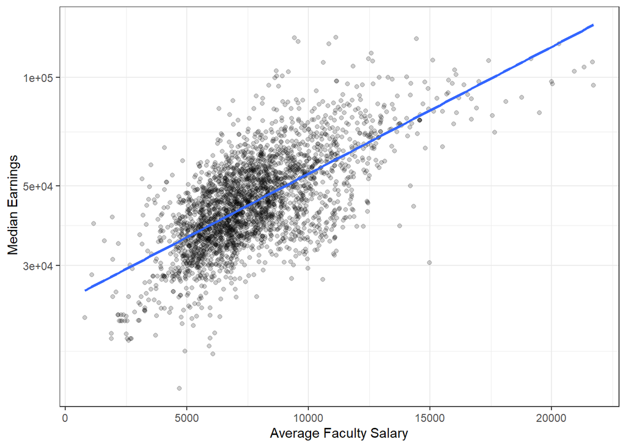

```r
ggplot(data = college.2, mapping = aes(x = AVGFACSAL, y = MD_EARN_WNE_P10))+
  geom_point(alpha = 0.2)+
  theme_bw()+
  geom_smooth(method = lm, se = FALSE)+
  labs(x = "Average Faculty Salary", y = " Median Earnings")+
  scale_y_log10()
```

2. Interpret the plots about the potential relationships.

There is a positive linear relationship between the two variables.

3. Why did `geom_smooth()` chose the `mgcv::gam()` smoothing method.

geom_smooth choosing the smoothing method based on the size of the largest group.

4. Why is there no `ICLEVEL` 3 plot, or, if there is a plot, why is there no data in the `ICLEVEL` 3 plot?

I am not sure.

5. Use `lm()` to run a linear model of the relationship **for only those schools with ICLEVEL 1** and save the results.

```r
lm <- lm(college.2$AVGFACSAL ~ college.2$ICLEVEL)
```

6. Use `summary()` on the results.

```r
summary(lm)
```

```
Call:
lm(formula = college.2$AVGFACSAL ~ college.2$ICLEVEL)

Residuals:
    Min      1Q  Median      3Q     Max
-7194.3 -1572.2  -338.1  1292.8 13724.7

Coefficients:
                  Estimate Std. Error t value Pr(>|t|)
(Intercept)         8931.4      139.3  64.098   <2e-16 ***
college.2$ICLEVEL   -936.2      100.2  -9.347   <2e-16 ***
---
Signif. codes:  0 '***' 0.001 '**' 0.01 '*' 0.05 '.' 0.1 ' ' 1

Residual standard error: 2469 on 2829 degrees of freedom
  (228 observations deleted due to missingness)
Multiple R-squared:  0.02996,   Adjusted R-squared:  0.02962
F-statistic: 87.37 on 1 and 2829 DF,  p-value: < 2.2e-16
```

7. Interpret the results of the model based on the coefficient for `AVGFACSAL` and the model $p$-value and adjusted $r$-squared value.

8. Given the adjusted $r$-squared value, what do you recommend to try to better predict average earnings of working students ten years after initial enrollment at ICLEVEL 1 schools?

Given the small r-squared value, I would recommend a larger sample size to try to minize larger discrepencies in the data.

```r
#college.2 %>%
 # mutate(ICLEVEL = as.factor(ICLEVEL),
  #       ICLEVEL = fct_recode(ICLEVEL,
    #                      "4-year" = "1",
     #                     "2-year" = "2",
      #                    "Less than 2-year" = "3"),
   #      ICELEVEL = fct_rev(ICLEVEL)) %>%
  #ggplot(aes(x = ICLEVEL, y = MN_EARN_WNE_P10)) +
  #scale_y_log10()+
  #geom_boxplot()+
  #theme_bw()
```

3. Use `aov()` to test if all of the institution levels have the same true mean of logged median earnings of working students ten years after enrollment.

```r
aov <- aov(college.2$AVGFACSAL ~ college.2$ICLEVEL)
```

4. Use `broom::tidy()` to show the results. Interpret the results

```r
broom::tidy(aov)
```

```
# A tibble: 2 × 6
  term                 df        sumsq     meansq statistic   p.value
  <chr>             <dbl>        <dbl>      <dbl>     <dbl>     <dbl>
1 college.2$ICLEVEL     1   532478156. 532478156.      87.4  1.77e-20
2 Residuals          2829 17240478241.   6094195.      NA   NA
```

5. Why would we look at the log of mean earnings instead of the un-logged values?

To reduce skewdness and variablility within the data.

```r
#college.2 %>%
 # ggplot(mapping = aes(x = FEMALE, y = MD_EARN_WNE_P10)) +
  #geom_point(alpha = 0.5) +
  #theme_bw() +
  #geom_smooth(se = FALSE) +
  #labs(x = "Percent Enrollment of Women Undergraduates", y = "Log(10) of Median Earnings") +
  #ggtitle("Log of Median Earnings by Percent Women Undergraduates")
```

3. Show the `INSTNM`, `INSTURL`, `RELAFFIL`, and `UGDS_WOMEN` for only schools with either 0% or 100% for `UGDS_WOMEN` sorted by ascending `UGDS_WOMEN` then `INSTNM`. There should be 39 schools. What do you notice?
   - Note: `RELAFFIL` of 30 is Roman Catholic, 66 is Presbyterian Church (USA), 71 is United Methodist, and 80 is Jewish.

```r
college.2 %>%
  group_by(INSTNM, INSTURL, RELAFFIL, UGDS_WOMEN) %>%
  filter(UGDS_WOMEN == 0 | UGDS_WOMEN == 100) %>%
  arrange(UGDS_WOMEN) %>%
  arrange(INSTNM)
```

```
# A tibble: 46 × 48
# Groups:   INSTNM, INSTURL, RELAFFIL, UGDS_WOMEN [46]
   ADM_RATE AGE_ENTRY AVGFACSAL CITY          CONTROL COSTT4_A ENDOWBEGIN FEMALE
      <dbl>     <dbl>     <dbl> <chr>           <dbl>    <dbl>      <dbl>  <dbl>
 1    0.588      22.1      4749 Lakewood            2    12500         NA     NA
 2   NA          18.5      1668 Spring Valley       2    17445         NA     NA
 3    0.771      19.6     10775 Far Rockaway        2    18500         NA     NA
 4   NA          23.7      7690 Lakewood            2       NA   12200008     NA
 5    0.652      18.3      4058 Monsey              2    21000         NA     NA
 6    0.922      19.6      3162 Brooklyn            2    25368         NA     NA
 7   NA          NA        4600 Brooklyn            2    25500         NA     NA
 8   NA          17.8      2074 Ossining            2    14775         NA     NA
 9    0.949      19        4924 Brooklyn            2    28697         NA     NA
10    0.72       23.4      3045 Brooklyn            2    24672    1260775     NA
# ℹ 36 more rows
# ℹ 40 more variables: FIRST_GEN <dbl>, GRAD_DEBT_MDN <dbl>, HBCU <dbl>,
#   HSI <dbl>, ICLEVEL <dbl>, INSTNM <chr>, INSTURL <chr>,
#   MD_EARN_WNE_P10 <dbl>, NANTI <dbl>, OPEID <chr>, PCIP13 <dbl>,
#   PCIP14 <dbl>, PCIP27 <dbl>, PCIP52 <dbl>, PCT_ASIAN <dbl>, PCT_BLACK <chr>,
#   PCT_HISPANIC <dbl>, PCT_WHITE <dbl>, PCTPELL <dbl>, PFTFAC <dbl>,
#   PREDDEG <dbl>, RELAFFIL <dbl>, SAT_AVG <dbl>, SCH_DEG <dbl>, …
```

4. To minimize extreme value effects, filter to choose schools where `UGDS_WOMEN` is greater than 10% and less than 90% and reproduce the plot.
   - Extra Credit: Add points and labels for American University (colored red) and the Massachusetts Institute of Technology (colored green) such that the points will automatically adjust with new data.

```r
#college.2 %>%
 # group_by(INSTNM, INSTURL, RELAFFIL, UGDS_WOMEN) %>%
  #filter(UGDS_WOMEN > 10 | UGDS_WOMEN < 90) %>%
  #arrange(UGDS_WOMEN) %>%
  #arrange(INSTNM) %>%
  #ggplot(aes(x = UGDS_WOMEN))
```

6. Filter out the schools with `UGDS_WOMEN` less than 10% or greater than 90% and use `lm()` to run a linear model and use `summary()` on the results

```r
lm.2 <- lm(college.2$UGDS_WOMEN ~ college.2$INSTNM)
summary(lm.2)
```

[output not shown]

[output cut: 15119 more lines]

[output not shown]

7. Interpret the results compared to the plot using the sign of the coefficient for `UGDS_WOMEN`, and the model $p$-value and adjusted R-squared.

[figure not shown]

```r
college.2 %>%
  select(INSTNM, GRAD_DEBT_MDN, MD_EARN_WNE_P10) %>%
  mutate(ROI = MD_EARN_WNE_P10/GRAD_DEBT_MDN) %>%
  arrange(desc(ROI)) -> debtratio
MDranking <- debtratio[complete.cases(debtratio), ]
MDranking %>%
  ggplot(aes(x = ROI))+
  geom_histogram(bins = 50)+
  theme_bw()+
  labs(title = "Ratio of Median Debt at Graduation to Average Annual Cost to Attend")+
  geom_vline(aes(xintercept = MDranking$ROI[MDranking$INSTNM == "American University"]),
             colour = "red", linetype = 5)+
  geom_text(x = 2.2, y = -6, label = "AU",
            size = 6, colour = "red")
```

# 2 World Bank Data

The World Bank provides loans to countries with the goal of reducing poverty. The data frames in the data folder were taken from the public data repositories of the [World Bank Group DataBank](https://databank.worldbank.org/home). The fertility, life expectancy, and population data are from its [World Development Indicators (WDI)](https://databank.worldbank.org/source/world-development-indicators) as of 1 August 2024.

- `wb_country_income_classification_2023.csv`: Contains information on the countries in the data set. Also includes totals for the regions (sets of countries) and the world. Source is [World Bank Country and Lending Groups](https://datahelpdesk.worldbank.org/knowledgebase/articles/906519-world-bank-country-and-lending-groups). The variables are: see HTML file
1. Use a relative path and a {readr} function to load each of these four files into its own tibble. *Be sure to look at the data after loading to ensure it loaded as expected, without problems, and fix any problems using {readr} function arguments.* Consider using the `problems()` function to identify the locations of any problems.
   - Note: `wb_country_income_classification_2023` has a row of all `NA`s between the countries and the collective economies such as regions. The argument `skip_empty_rows` defaults to `TRUE` but, since there are commas in the file, the row is not counted as “empty.”
   - Note: Some countries have `NA` for missing data for the early years but have values in the later years which is not a problem.
   - There should be a maximum of 267 rows for the country data and 266 rows for each of the WDI data files.

```r
country <- read.csv("C:/Users/savan/OneDrive/Documents/master's program - AU/Fall 2024/Data 613/wb_country_income_classification_2023.csv")

fertility <- read.csv("C:/Users/savan/OneDrive/Documents/master's program - AU/Fall 2024/Data 613/wb_fertility_2022.csv")

life_exp <- read.csv("C:/Users/savan/OneDrive/Documents/master's program - AU/Fall 2024/Data 613/wb_fertility_2022.csv")

population <- read.csv("C:/Users/savan/OneDrive/Documents/master's program - AU/Fall 2024/Data 613/wb_fertility_2022.csv")
```

2. Use `anti_join()` to show which codes are in the country data but not in the population data and which country codes are in population data but not in the country data. What do you notice?
3. These data are messy. The observational units in `fert`, `life`, and `pop` are locations in space-time (e.g., Aruba in 2020). Recall that “tidy” data should have one observational unit per row.
- Using only two function calls for each data frame, tidy each data frame to have only four variables by:
  1. Removing the `Indicator Name` and `Indicator Code` columns.
  2. Using a {tidyr} function to tidy the tibble, and, by using an argument of the function and a {readr} function ensure the variable for `year` is a numeric. Recall, {readr} parsing functions can “fix” many parsing errors automatically. There should be no need to use a `mutate()` function.
  3. Given the many `NA`s, remove them using an argument of the {tidyr} function.
  4. Save each tidy tibble to a new name.
  5. You should have four columns in each with 16,124, 16,137, and 16,930 rows based on the different numbers of `NA`s in the original tibbles. The `INX` country code had all `NA`s for each year so it should be gone as well.
- Show the first 6 rows for each tibble.

```r
#fertility %>%
 # pivot_longer(cols = "1960":"2018",
  #             names_to = "Year",
   #            values_to = "fertility_rate",
    #           values_ptypes = list(factor())) %>%
  #mutate(Year = parse_number(Year)) -> fertility.tidy

#life_exp %>%
 # pivot_longer(cols = "1960":"2018",names_to = "Year",
  #               values_to = "life_expectancy", values_ptypes = list(factor())) %>%
  #mutate(Year = parse_number(Year)) -> life_exp.tidy

#population %>%
 #   pivot_longer(cols = "1960":"2018",names_to = "Year",
  #               values_to = "population", values_ptypes = list(factor())) %>%
  #mutate(Year = parse_number(Year)) -> population.tidy
```

4. Combine tibbles.
1. Using a {dplyr} join function, *join* the three WDI tidy tibbles you just created into a single tibble. Start with the population data and then join fertility data and then join the life_expectancy data.
   - It should have six columns and 16,930 rows.

```r
#country %>%
#left_join(fertility.tidy, by = "Country Code") %>%
#left_join(life_exp.tidy, by = c("Country Code", "Year", "Country Name")) %>%
#left_join(population.tidy, by = c("Country Code", "Year", "Country Name")) %>%
 # rename(Country = "Country Name") -> wb
```

```r
#wb %>%
 # filter(Year == 1960 | Year == 1970 | Year == 1980 | Year == 1990 | Year == 2000 | Year == 2010) %>%
  #rename("Population" = population) %>%
 #ggplot(mapping = aes(x = life_expectancy, y = fertility_rate ,
  #                   color = Region, size = Population), na.rm = TRUE)+
 #geom_point()+
  #ggtitle(" Changes by Region across Decades")+
#xlab("Life Expectancy")+
 # ylab("Fertility Rate")+
  #scale_color_colorblind() +
#facet_wrap(~Year)+
#theme(strip.background = element_blank(), strip.placement = "outside")
```

```r
#wb %>%
 # select(Region, Year, population) %>%
  #filter(Year != 2018) %>%
  #group_by(Year, Region) %>%
  #mutate(ttl_population = sum(population), na.rm = TRUE) -> WBdata_noNA_no2018

  #ggplot(data = WBdata_noNA_no2018, mapping = aes(x = Year, y = ttl_population, color = Region))+
   # geom_line()+
    #labs(x = "Years", y = "Log of Total Population")+
    #ggtitle("Population by Region")+
    #theme_bw()+
    #scale_y_log10()+
    #scale_color_colorblind()
```

8. Percentage population growth for the countries from 1960 to 2020 (Extra Credit)
1. Make a box plot of the percentage population growth for the countries from 1960 to 2020 (the population in 2020 compared to 1960) with the following attributes.
   1. Use code to automatically order the Regions on the $y$-axis in **increasing** order of Region’s total 1960 population.
   2. For any countries with negative growth, set it to .001.
   3. Add a red line at 100%.

```r
#wb %>%
 # select(Region, population, Year) %>%
  #group_by(Region) %>%
  #summarise(ttl_population = sum(population)) %>%
  #ggplot(mapping = aes(x = reorder(Region, -ttl_population), y = ttl_population))+
  #geom_boxplot(stat = "identity")+
  #coord_flip()+
   # ggtitle("Population Change by Country Within Each Region")+
    #xlab("Percent Change in Population")+
  #theme_bw()
```